# R Notebook

Use `cancensus` to check and download census data. Check the regions:

```r
list_census_regions('CA16') %>%
  filter(level == "CMA", name %in% c("Hamilton"))
```

```
Reading regions list from local cache.
```

| region | name | level | pop | municipal_status | CMA_UID | CD_UID | PR_UID |
| --- | --- | --- | --- | --- | --- | --- | --- |
| 35537 | Hamilton | CMA | 747545 | B | NA | NA | 35 |

We need PR_UID 35.

List census data sets:

```r
list_census_datasets()
```

```
Reading dataset list from temporary cache.
```

| dataset | description | geo_dataset | attribution | reference | reference_url |
| --- | --- | --- | --- | --- | --- |
| CA1996 | 1996 Canada Census | CA1996 | StatCan 1996 Census | 92-351-U | https://www150.statcan.gc.ca/n1/en/catalogue/92-351-U |
| CA01 | 2001 Canada Census | CA01 | StatCan 2001 Census | 92-378-X | https://www150.statcan.gc.ca/n1/en/catalogue/92-378-X |
| CA06 | 2006 Canada Census | CA06 | StatCan 2006 Census | 92-566-X | https://www150.statcan.gc.ca/n1/en/catalogue/92-566-X |
| CA11 | 2011 Canada Census and NHS | CA11 | StatCan 2011 Census and NHS | 98-301-X, 99-000-X | https://www12.statcan.gc.ca/census-recensement/2011/ref/index-eng.cfm |
| CA16 | 2016 Canada Census | CA16 | StatCan 2016 Census | 98-301-X | https://www150.statcan.gc.ca/n1/en/catalogue/98-301-X |
| CA01xSD | 2001 Canada Census xtab - Structural type by Document type | CA01 | StatCan 2001 Census xtab, via CMHC | 92-378-X | https://www150.statcan.gc.ca/n1/en/catalogue/92-378-X |
| CA06xSD | 2006 Canada Census xtab - Structural type by Document type | CA06 | StatCan 2006 Census xtab, via CMHC | 92-566-X | https://www150.statcan.gc.ca/n1/en/catalogue/92-566-X |
| CA11xSD | 2011 Canada Census xtab - Structural type by Document type | CA11 | StatCan 2011 Census xtab, via CMHC | 98-301-X | https://www150.statcan.gc.ca/n1/en/catalogue/98-301-X |
| CA16xSD | 2016 Canada Census xtab - Structural type by Document type | CA16 | StatCan 2016 Census xtab, via CMHC | 98-301-X | https://www150.statcan.gc.ca/n1/en/catalogue/98-301-X |
| TX2000 | 2000 T1FF taxfiler data | CA1996 | StatCan 2000 T1FF, via CMHC | 72-212-X | https://www150.statcan.gc.ca/n1/en/catalogue/72-212-X |

[output cut: 18 more lines]

We need CA16.

```r
find_census_vectors("median household income",
                    dataset = "CA16",
                    type = "total",
                    query_type = "keyword",
                    interactive = FALSE)
```

| vector | type | label | details |
| --- | --- | --- | --- |
| v_CA16_2397 | Total | Median total income of households in 2015 ($) | Income; Households; Total - Income statistics in 2015 for private households by household size - Median total income of households in 2015 ($) |
| v_CA16_2398 | Total | Median after-tax income of households in 2015 ($) | Income; Households; Total - Income statistics in 2015 for private households by household size - Median after-tax income of households in 2015 ($) |

We need v_CA16_2397.

Retrieve data:

```r
mhi <- get_census(dataset='CA16',
                          regions=list(CMA=c("35537")),
                          vectors=c("v_CA16_2397"),
                          level='DA',
                          use_cache = FALSE)
```

```
Querying CensusMapper API...
```

```
Downloading: 16 kB
Downloading: 16 kB
Downloading: 23 kB
Downloading: 23 kB
Downloading: 23 kB
Downloading: 23 kB
```

Join median household income to accessibility by DA:

```r
accessibility_da <- accessibility_da %>%
  left_join(mhi %>%
              transmute(DA = GeoUID,
                        median_household_income = `v_CA16_2397: Median total income of households in 2015 ($)`),
            by = "DA")
```

Summary of median household income:

```r
summary(accessibility_da$median_household_income)
```

```
   Min. 1st Qu.  Median    Mean 3rd Qu.    Max.
  10771   40000   48320   54435   60288  218624
```

Bivariate choropleth maps of accessibility and income:

```r
library(biscale)
library(cowplot)
```

Create a class for bivariate plotting (drop DA with missing income data):

```r
data <- bi_class(accessibility_da %>%
                   drop_na(),
                 x = accessibility_o,
                 y = median_household_income,
                 style = "quantile",
                 dim = 3) %>%
  st_as_sf()
```

Plot accessibility of original system without ERI hubs:

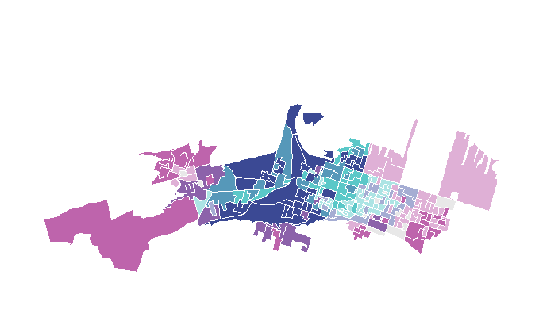

```r
 map <- ggplot() +
  geom_sf(data = data, mapping = aes(fill = bi_class), color = "white", size = 0.1, show.legend = FALSE) +
  bi_scale_fill(pal = "DkBlue", dim = 3) +
  bi_theme()

map
```

Create legend:

```r
legend <- bi_legend(pal = "DkBlue",
                    dim = 3,
                    xlab = "Higher accessibility ",
                    ylab = "Higher income",
                    size = 6)
```

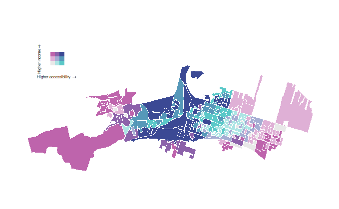

```r
 cowplot::ggdraw() +
  cowplot::draw_plot(map, 0, 0, 1, 1) +
  cowplot::draw_plot(legend, 0.05, .6, 0.2, 0.2)
```

Create a class for bivariate plotting (drop DA with missing income data):

```r
data_equity <- bi_class(accessibility_da %>%
                   drop_na(),
                 x = accessibility,
                 y = median_household_income,
                 style = "quantile",
                 dim = 3) %>%
  st_as_sf()
```

Plot accessibility of original system with ERI hubs:

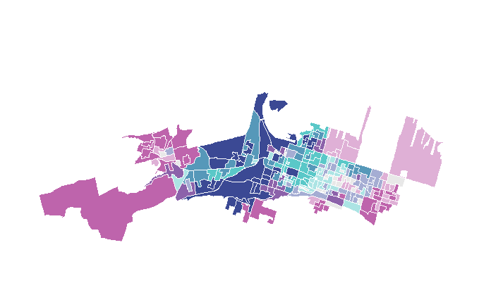

```r
 map_equity <- ggplot() +
  geom_sf(data = data_equity, mapping = aes(fill = bi_class), color = "white", size = 0.1, show.legend = FALSE) +
  bi_scale_fill(pal = "DkBlue", dim = 3) +
  bi_theme()

map_equity
```

Create legend:

```r
legend_equity <- bi_legend(pal = "DkBlue",
                    dim = 3,
                    xlab = "Higher accessibility ",
                    ylab = "Higher income",
                    size = 6)
```

Finalize plot of accessibility with ERI hubs:

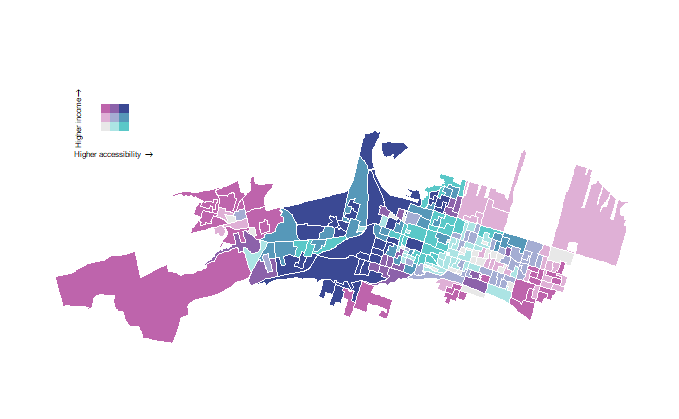

```r
 cowplot::ggdraw() +
  cowplot::draw_plot(map_equity, 0, 0, 1, 1) +
  cowplot::draw_plot(legend, 0.05, .6, 0.2, 0.2)
```

Save data files:

```r
save(accessibility_da, file = "accessibility.RData")
save(map, file = "accessibility_map_original.RData")
save(map_equity, file = "accessibility_map_equity.RData")
save(mhi, file = "mhi.RData")
save(population_sobi_original, file = "population_sobi_original.RData")
```